# `PTCMGH` R package: Promotion Time Cure Models with a General Hazard structure

[Francisco Javier Rubio](https://sites.google.com/site/fjavierrubio67/)

# Promotion Time Cure Models

Promotion-Time Cure Models (PTCMs) are a class of survival regression models in which a subset of the population is assumed to be cured (Yakovlev and Tsodikov 1996; Tsodikov 1998; M. H. Chen, Ibrahim, and Sinha 1999; Amico and Van Keilegom 2018), that is, never to experience the event of interest. Equivalently, this sub-population is characterised by infinite survival times. The survival function of a PTCM is given by:

$$S_c(t) = \exp\left\{ -\theta \tilde{F}(t) \right\}, \quad t \geq 0,$$
where $\theta>0$ is a positive parameter, and $\tilde{F}$ is a cumulative distribution function with support on ${\mathbb R}_+$. Note that

$$\lim_{t\to\infty} S_c(t) = \exp\{-\theta\},$$
which represents the cured fraction. Since the survival function associated with the PTCM does not decrease to zero, it is often referred to as an “improper” survival function (Peng and Yu 2021).

If covariates ${\bf x} \in {\mathbb R}^p$ are available, they can be incorporated into the two components of the PTCM:

1. Let ${\bf w} \subseteq {\bf x}$, and model the log-link $\theta({\bf w}) = \exp({\alpha_0+\bf w}^{\top}{\boldsymbol{\alpha}})$, where $\alpha_0$ is an intercept.
2. Let ${\bf z} \subseteq {\bf x}$, and model the hazard structure as $\tilde{H}(t \mid {\bf z})$. Then, we can define

$$\tilde{F}(t \mid {\bf z}) = 1 - \exp\{-\tilde{H}(t \mid {\bf z})\}.$$
The hazard structure $\tilde{H}(t \mid {\bf z})$ can include the proportional hazards, the accelerated failure time, or more general hazard structures (Rubio et al. 2019).

## Proportional Hazards (PH)

Suppose that the hazard and cumulative hazard functions follow a proportional hazards (PH) structure:

$$\begin{align}
\tilde{h}(t \mid {\bf z}) &= \tilde{h}_0(t \mid \boldsymbol{\gamma})
\exp\{{\bf z}^{\top} \boldsymbol{\beta}\}, \\
\tilde{H}(t \mid {\bf z}) &= \tilde{H}_0(t \mid \boldsymbol{\gamma})
\exp\{{\bf z}^{\top} \boldsymbol{\beta}\},
\end{align}$$

where $\tilde{h}_0$ is a baseline hazard associated with a distribution $\tilde{F}_0$, with parameters $\boldsymbol{\gamma}$. Let also $\theta({\bf w}) = \exp({\bf w}^{\top}{\boldsymbol{\alpha}})$, and $u$ be a realisation from a $U(0,1)$ distribution. A simulation from the PTCM with a PH structure (PTCM-PH) can then be obtained as follows:

$$t^* = \tilde{F}_0^{-1}\left( 1 - \exp\left\{ \exp\left\{ - {\bf
z}^{\top}\boldsymbol{\beta} \right\}\log\left[ 1 +
\log(u)\exp\left\{-\alpha_0 - {\bf
w}^{\top}\boldsymbol{\alpha} \right\} \right] \right\} \right).$$
if $1 + \log(u)\exp\left\{-\alpha_0 - {\bf w}^{\top}\boldsymbol{\alpha} \right\}>0$, and $t^*=\infty$ otherwise.

## Accelerated Failure Time (AFT)

Suppose that the hazard and cumulative hazard functions follow an accelerated failure time (AFT) hazard structure:

$$\begin{align}
\tilde{h}(t \mid {\bf z}) &= \tilde{h}_0(t \exp\{{\bf z}^{\top}
\boldsymbol{\beta}\} \mid \boldsymbol{\gamma}) \exp\{{\bf z}^{\top}
\boldsymbol{\beta}\}, \\
\tilde{H}(t \mid {\bf z}) &= \tilde{H}_0(t \exp\{{\bf z}^{\top}
\boldsymbol{\beta}\} \mid \boldsymbol{\gamma}) ,
\end{align}$$

## General Hazards (GH)

Suppose that the hazard and cumulative hazard functions follow a General Hazard (GH) structure (Y. Q. Chen and Jewell 2001) (Rubio et al. 2019):

$$\begin{align}
\tilde{h}(t \mid {\bf z}) &= \tilde{h}_0(t \exp\{{\bf z}^{\top}
\boldsymbol{\eta}\} \mid \boldsymbol{\gamma}) \exp\{{\bf z}^{\top}
\boldsymbol{\beta}\}, \\
\tilde{H}(t \mid {\bf z}) &= \tilde{H}_0(t \exp\{{\bf z}^{\top}
\boldsymbol{\eta}\} \mid \boldsymbol{\gamma}) \exp\{{\bf z}^{\top}
\boldsymbol{\beta} - {\bf z}^{\top} \boldsymbol{\eta}\}\},
\end{align}$$

where $\tilde{h}_0$ is a baseline hazard associated with a distribution $\tilde{F}_0$, with parameters $\boldsymbol{\gamma}$. Let also $\theta({\bf w}) = \exp({\bf w}^{\top}{\boldsymbol{\alpha}})$, and $u$ be a realisation from a $U(0,1)$ distribution. A simulation from the PTCM with a GH structure (PTCM-GH) can then be obtained as follows:

$$t^* = \exp\left\{ - {\bf z}^{\top}\boldsymbol{\eta} \right\}
\tilde{F}_0^{-1}\left( 1 - \exp\left\{ \exp\left\{ {\bf
z}^{\top}\boldsymbol{\eta} - {\bf z}^{\top}\boldsymbol{\beta}
\right\}\log\left[ 1 + \log(u)\exp\left\{-\alpha_0 - {\bf
w}^{\top}\boldsymbol{\alpha} \right\} \right] \right\} \right).$$
if $1 - \exp\left\{ \exp\left\{ {\bf z}^{\top}\boldsymbol{\eta} - {\bf z}^{\top}\boldsymbol{\beta} \right\}\log\left[ 1 + \log(u)\exp\left\{-\alpha_0 - {\bf w}^{\top}\boldsymbol{\alpha} \right\} \right] \right\} < 1$, and $t^*=\infty$ otherwise.

## A general simulation strategy

Provided that one can simulate from the distribution $\tilde{F}(t \mid {\bf z})$ using numerical methods, simulating from a PTCM can be accomplished simply by generating $u \sim U(0,1)$ and solving:

$$t^* = \tilde{F}\left( -\log(u) \exp\left\{-\alpha_0 - {\bf
w}^{\top}\boldsymbol{\alpha} \right\} \mid {\bf z} \right)$$
if $-\log(u) \exp\left\{-\alpha_0 - {\bf w}^{\top}\boldsymbol{\alpha} \right\} < 1$, and $t^*=\infty$ otherwise.

# Maximum Likelihood Estimation

## Model with no covariates (baseline)

The log-likelihood function of the parameters $\Psi = (\theta, \boldsymbol{\gamma}^{\top})^{\top}$ is:

$$\begin{align}
\ell\left( \Psi \right) &= \sum_{i=1}^n \delta_i \log h(t_i \mid
\Psi) - \sum_{i=1}^n H(t_i \mid \Psi)\\
&= \sum_{i=1}^n \delta_i \log(\theta) + \sum_{i=1}^n \delta_i \log
\tilde{h}(t_i \mid \boldsymbol{\gamma}) - \sum_{i=1}^n \delta_i
\tilde{H}(t_i \mid \boldsymbol{\gamma})\\
&+ \sum_{i=1}^n \theta \left[ 1 - \exp\left\{ -\tilde{H}(t_i \mid
\boldsymbol{\gamma}) \right\} \right]\\
&= n_O \log(\theta) + \sum_{i=1}^n \delta_i \log \tilde{h}(t_i \mid
\boldsymbol{\gamma}) - \sum_{i=1}^n \delta_i \tilde{H}(t_i \mid
\boldsymbol{\gamma})\\
&- n\theta - \theta \sum_{i=1}^n \exp\left\{ -\tilde{H}(t_i \mid
\boldsymbol{\gamma}) \right\},
\end{align}$$

where $n_O = \sum_{i=1}^n \delta_i$.

## Models with covariates: PH, AFT, AH, GH

The log-likelihood function of the model parameters $\Psi = (\alpha_0,\boldsymbol{\alpha}^{\top}, \boldsymbol{\beta}^{\top}, \boldsymbol{\eta}^{\top}, \boldsymbol{\gamma}^{\top})^{\top}$ is:

$$\begin{align}
\ell\left( \Psi \right) &= \sum_{i=1}^n \delta_i \log h(t_i \mid
\Psi, \boldsymbol{z}_i) - \sum_{i=1}^n H(t_i \mid \Psi,
\boldsymbol{z}_i)\\
&= \sum_{i=1}^n \delta_i \boldsymbol{w}_i^{\top}\boldsymbol{\alpha}
+ \sum_{i=1}^n \delta_i \log \tilde{h}(t_i \mid \boldsymbol{\gamma},
\boldsymbol{z}_i) - \sum_{i=1}^n \delta_i \tilde{H}(t_i \mid
\boldsymbol{\gamma}, \boldsymbol{z}_i)\\
&- \sum_{i=1}^n
\exp\{\boldsymbol{w}_i^{\top}\boldsymbol{\alpha}\} + \sum_{i=1}^n
\exp\left\{\boldsymbol{w}_i^{\top}\boldsymbol{\alpha} -\tilde{H}(t_i
\mid \boldsymbol{\gamma}, \boldsymbol{z}_i) \right\}.
\end{align}$$

# `PTCMGH` R package

The `PTCMGH` R package provides functions for simulating survival times from PTCMs with proportional hazards, accelerated failure time, and general hazard structures under a log-link for $\theta$, as well as for performing maximum likelihood estimation of these models. The hazard structure used for modelling $\tilde{F}$ can include the proportional hazards, the accelerated failure time, or more [general hazard structures](https://doi.org/10.1177/0962280218782293).

- General Hazard (GH) model.
- Accelerated Failure Time (AFT) model.
- Proportional Hazards (PH) model.
- Accelerated Hazards (AH) model.

These models are fitted using the R commands `nlminb` and `optim`. Thus, the user needs to specify the initial points and to check the convergence of the optimisation step, as usual.

The current version of the `PTCMGH` R package implements the following parametric baseline hazards for the models discussed in the previous section, using the command `PTCMMLE`.

- [Power Generalised Weibull](http://rpubs.com/FJRubio/PGW) (PGW) distribution.
- [Exponentiated Weibull](http://rpubs.com/FJRubio/EWD) (EW) distribution.
- [Generalised Gamma](http://rpubs.com/FJRubio/GG) (GenGamma) distribuiton.
- [Gamma](https://en.wikipedia.org/wiki/Gamma_distribution) (Gamma) distribution.
- [Lognormal](https://en.wikipedia.org/wiki/Log-normal_distribution) (LogNormal) distribution.
- [Log-logistic](https://en.wikipedia.org/wiki/Log-logistic_distribution) (LogLogistic) distribution.
- [Weibull](https://en.wikipedia.org/wiki/Weibull_distribution) (Weibull) distribution. (only for AFT, PH, and AH models)

All positive parameters are transformed into the real line using a `log` link (reparameterisation).

The `PTCMGH` R package depends on functions from the [`HazReg` R package](https://github.com/FJRubio67/HazReg), which must also be installed and loaded.

**Disclaimer**: Although this R package implements several hazard structures, some models may exhibit practical non-identifiability if the follow-up period is not sufficiently long (Rubio, Espindola, and Montoya 2023). Users should verify this (e.g., by plotting parameter profile likelihoods). A potential remedy is to fit simpler models, though pathological cases may still arise where the cure model is difficult to estimate due to limited follow-up or high censoring rates. Such issues are well documented in the literature (Lambert and Bremhorst 2019).

A list of R packages implementing different types of cure survival models can be found at: [CRAN Task View: Survival Analysis](https://cran.r-project.org/web/views/Survival.html)

# R code

The following R code illustrates how to simulate survival times from a PTCM-GH model and perform maximum likelihood estimation for PTCMs with baseline, proportional hazards, accelerated failure time, accelerated hazards, and general hazard structures using a log-link for $\theta$, via the [`PTCMGH` R package](https://github.com/FJRubio67/PTCMGH).

## Simulation

```r
rm(list=ls())

#library(devtools)
#install_github("FJRubio67/HazReg")
library(HazReg)
#library(devtools)
#install_github("FJRubio67/PTCMGH")
library(PTCMGH)
library(survival)
library(knitr)

# ?simPTCMGH
# ?PTCMMLE

# Data simulation
n = 10000
seed = 123
set.seed(seed)
# Design matrix (includes the intercept in the first entry for theta)
des0 <- cbind(1, rnorm(n), rnorm(n))

# Simulation: PTCM with GH structure and LogNormal baseline hazard, and log-link
sim = simPTCMGH(n = n,
          seed = seed,
          hstr = "GH",
          dist = "LogNormal",
          des_theta = des0,
          des_t = des0[, -1],
          des_h = des0[, -1],
          des = NULL,
          par_base = c(-0.25, 0.1),
          alpha = c(0.5, 0.5, 0.5),
          beta_t = c(0.5, 0.5),
          beta_h = c(1.0, 1.0),
          beta = NULL)

# Inducing censoring
cens = 6
status <- ifelse(sim < cens, 1, 0)
mean(status)
```

```
## [1] 0.7631
```

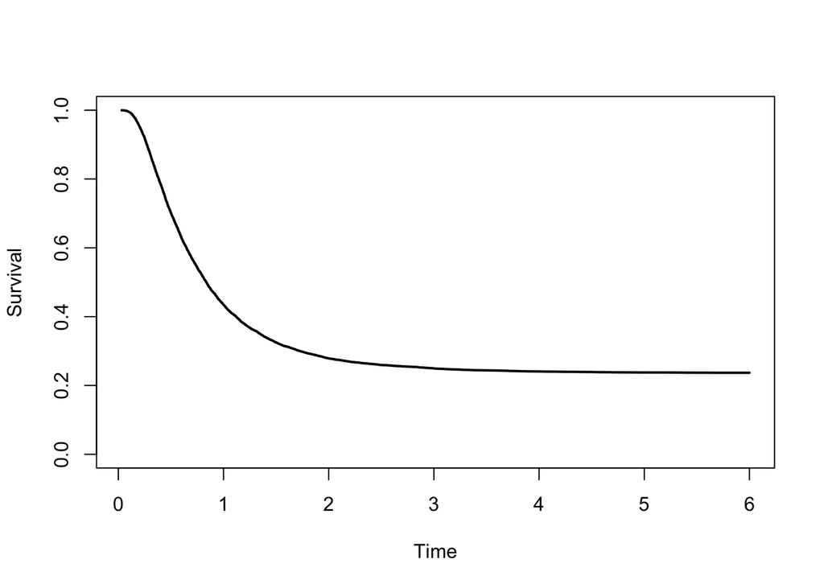

```r
times <- ifelse(sim< cens, sim, cens)

# Kaplan-Meier estimator for the survival times
km <- survfit(Surv(times, status) ~ 1)
plot(km$time, km$surv, type = "l", col = "black", lwd = 2, lty = 1,
     ylim = c(0,1), xlab = "Time", ylab = "Survival")
```

## Model fit: baseline

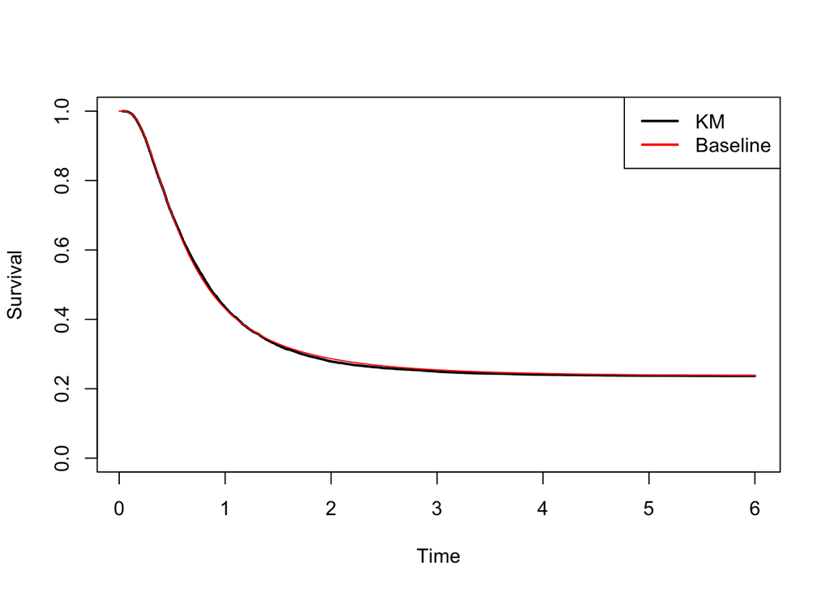

```r
# Model fitting
OPT <- PTCMMLE(init = c(0,0,0),
                    times = times,
                    status = status,
                    hstr = "baseline",
                    dist = "LogNormal",
                    des_theta = NULL,
                    des_t = NULL,
                    des_h = NULL,
                    des = NULL,
                    method = "nlminb",
                    maxit = 10000)

# MLE
MLE <- c(OPT$OPT$par[1],exp(OPT$OPT$par[2]),exp(OPT$OPT$par[3]))

# Fitted survival function
spt <- Vectorize(function(t) exp(- MLE[3]*(1-exp(-chlnorm(t,MLE[1],MLE[2])))) )

plot(km$time, km$surv, type = "l", col = "black", lwd = 2, lty = 1,
     ylim = c(0,1), xlab = "Time", ylab = "Survival")
curve(spt,0,6, col = "red", add= T)
legend("topright", legend = c("KM","Baseline"), col = c("black","red"),
       lwd = c(2,2))
```

## Model fit: PH

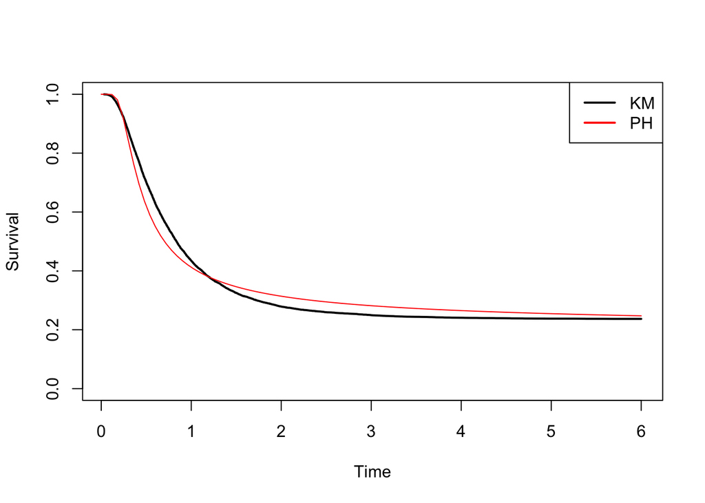

```r
# Model fitting
OPT_PH <- PTCMMLE(init = c(0,0,0,0,0,0,0),
               times = times,
               status = status,
               hstr = "PH",
               dist = "LogNormal",
               des_theta = des0,
               des_t = NULL,
               des_h = NULL,
               des = des0[,-1],
               method = "nlminb",
               maxit = 10000)

# MLE
MLE_PH <- c(OPT_PH$OPT$par[1],exp(OPT_PH$OPT$par[2]),OPT_PH$OPT$par[-c(1:2)])

# Population survival function
spt_ph <- Vectorize(function(t){

  theta_i <- as.vector(exp(des0 %*% MLE_PH[3:5]))
  F_i <- 1 - exp(-chlnorm(t,MLE_PH[1],MLE_PH[2])*exp(des0[,-1]%*%MLE_PH[6:7]))
  survs <- exp(-theta_i*F_i)
  return(mean(survs))
  })

plot(km$time, km$surv, type = "l", col = "black", lwd = 2, lty = 1,
     ylim = c(0,1), xlab = "Time", ylab = "Survival")
curve(spt_ph,0,6, col = "red", add= T)
legend("topright", legend = c("KM","PH"), col = c("black","red"),
       lwd = c(2,2))
```

# Model fit: AFT

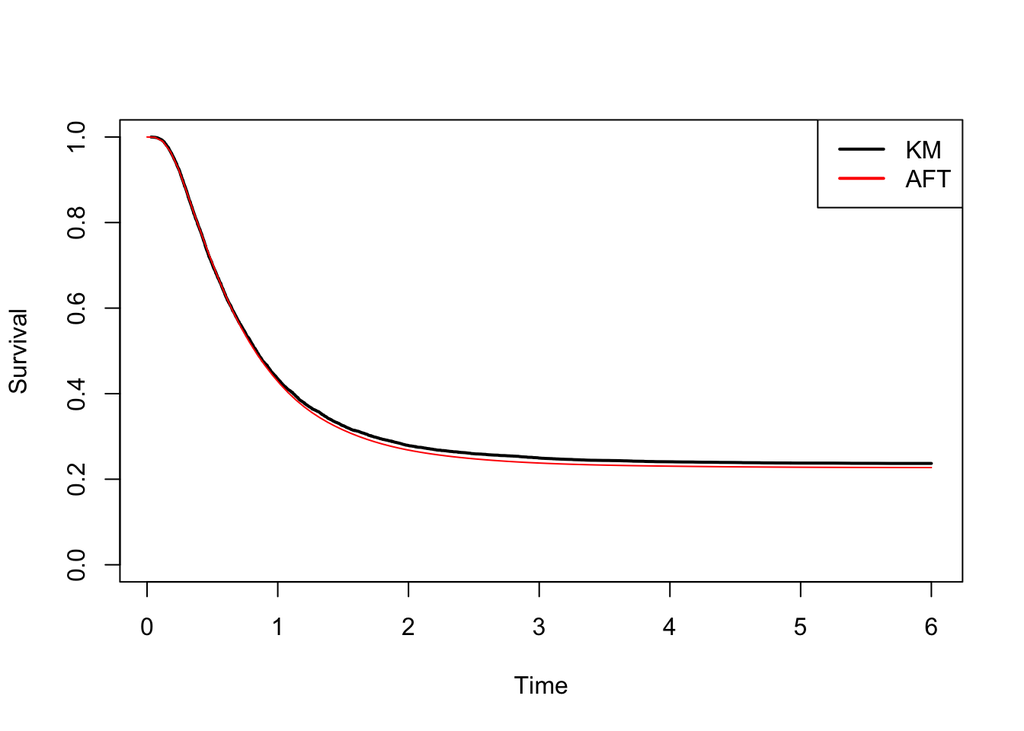

```r
# Model fitting
OPT_AFT <- PTCMMLE(init = c(0,0,0,0,0,0,0),
                  times = times,
                  status = status,
                  hstr = "AFT",
                  dist = "LogNormal",
                  des_theta = des0,
                  des_t = NULL,
                  des_h = NULL,
                  des = des0[,-1],
                  method = "nlminb",
                  maxit = 10000)

# MLE
MLE_AFT <- c(OPT_AFT$OPT$par[1],exp(OPT_AFT$OPT$par[2]),OPT_AFT$OPT$par[-c(1:2)])

# Population survival function
spt_aft <- Vectorize(function(t){

  theta_i <- as.vector(exp(des0 %*% MLE_AFT[3:5]))
  F_i <- 1 - exp(-chlnorm(as.vector(t*exp(des0[,-1]%*%MLE_AFT[6:7])),MLE_AFT[1],MLE_AFT[2]))
  survs <- exp(-theta_i*F_i)
  return(mean(survs))
})


plot(km$time, km$surv, type = "l", col = "black", lwd = 2, lty = 1,
     ylim = c(0,1), xlab = "Time", ylab = "Survival")
curve(spt_aft,0,6, col = "red", add= T)
legend("topright", legend = c("KM","AFT"), col = c("black","red"),
       lwd = c(2,2))
```

# Model fit: Accelerated Hazards

```r
# Model fitting
OPT_AH <- PTCMMLE(init = c(0,0,0,0,0,0,0),
                   times = times,
                   status = status,
                   hstr = "AH",
                   dist = "LogNormal",
                   des_theta = des0,
                   des_t = des0[,-1],
                   des_h = NULL,
                   des = NULL,
                   method = "nlminb",
                   maxit = 10000)

MLE
```

```
## [1] -0.1641417  0.7747794  1.4431071
```

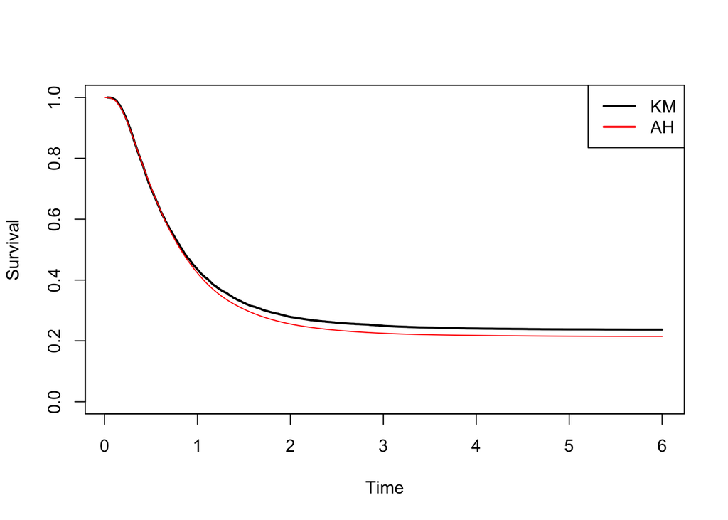

```r
MLE_AH <- c(OPT_AH$OPT$par[1],exp(OPT_AH$OPT$par[2]),OPT_AH$OPT$par[-c(1:2)])

# Population survival function
spt_ah <- Vectorize(function(t){

  theta_i <- as.vector(exp(des0 %*% MLE_AH[3:5]))
  F_i <- 1 - exp(-chlnorm(as.vector(t*exp(des0[,-1]%*%MLE_AH[6:7])),MLE_AH[1],MLE_AH[2])*as.vector(exp(-des0[,-1]%*%MLE_AH[6:7])))
  survs <- exp(-theta_i*F_i)
  return(mean(survs))
})

plot(km$time, km$surv, type = "l", col = "black", lwd = 2, lty = 1,
     ylim = c(0,1), xlab = "Time", ylab = "Survival")
curve(spt_ah,0,6, col = "red", add= T)
legend("topright", legend = c("KM","AH"), col = c("black","red"),
       lwd = c(2,2))
```

# Model fit: General Hazards

```r
# Model fitting
OPT_GH <- PTCMMLE(init = c(0,0,0,0,0,0,0,0,0),
                   times = times,
                   status = status,
                   hstr = "GH",
                   dist = "LogNormal",
                   des_theta = des0,
                   des_t = des0[,-1],
                   des_h = des0[,-1],
                   des = NULL,
                   method = "nlminb",
                   maxit = 10000)

# MLE
MLE_GH <- c(OPT_GH$OPT$par[1],exp(OPT_GH$OPT$par[2]),OPT_GH$OPT$par[-c(1:2)])

# Comparison: MLE vs true parameter values
cbind(MLE_GH, c(-0.25, 0.1,0.5, 0.5, 0.5,0.5, 0.5, 1.0, 1.0))
```

```
##            MLE_GH
##  [1,] -0.24967272 -0.25
##  [2,]  0.09894309  0.10
##  [3,]  0.49141439  0.50
##  [4,]  0.50155037  0.50
##  [5,]  0.49230559  0.50
##  [6,]  0.50103911  0.50
##  [7,]  0.49994272  0.50
##  [8,]  1.00742913  1.00
##  [9,]  1.02867217  1.00
```

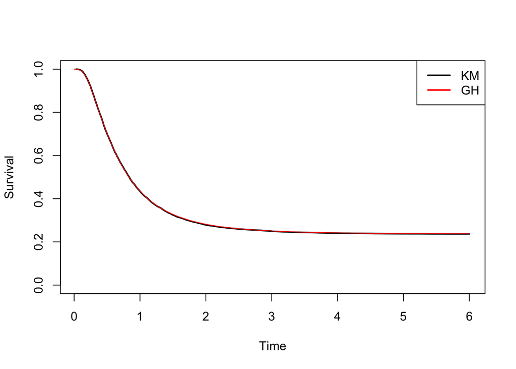

```r
# Population survival function
spt_gh <- Vectorize(function(t){

  theta_i <- as.vector(exp(des0 %*% MLE_GH[3:5]))
  F_i <- 1 - exp(-chlnorm(as.vector(t*as.vector(exp(des0[,-1]%*%MLE_GH[6:7]))),MLE_GH[1],MLE_GH[2])*as.vector(exp(des0[,-1]%*%MLE_GH[8:9] - des0[,-1]%*%MLE_GH[6:7])))
  survs <- exp(-theta_i*F_i)
  return(mean(survs))
})

plot(km$time, km$surv, type = "l", col = "black", lwd = 2, lty = 1,
     ylim = c(0,1), xlab = "Time", ylab = "Survival")
curve(spt_gh,0,6, col = "red", add= T)
legend("topright", legend = c("KM","GH"), col = c("black","red"),
       lwd = c(2,2))
```

```r
# Confidence intervals for the parameters (positive parameters transformed to log-scale)
CI_GH <- Conf_Int(OPT_GH$log_lik, OPT_GH$OPT$par, level = 0.95)
kable(CI_GH, digits = 3)
```

|  | Lower | Upper | Transf MLE | Std. Error |
| --- | --- | --- | --- | --- |
| par1 | -0.253 | -0.247 | -0.250 | 0.002 |
| par2 | -2.330 | -2.296 | -2.313 | 0.009 |
| par3 | 0.464 | 0.519 | 0.491 | 0.014 |
| par4 | 0.471 | 0.532 | 0.502 | 0.015 |
| par5 | 0.462 | 0.523 | 0.492 | 0.016 |
| par6 | 0.497 | 0.505 | 0.501 | 0.002 |
| par7 | 0.496 | 0.504 | 0.500 | 0.002 |
| par8 | 0.952 | 1.063 | 1.007 | 0.028 |
| par9 | 0.972 | 1.085 | 1.029 | 0.029 |

## Model comparison

```r
# Akaike information criterion
AIC <- 2*OPT$OPT$objective + 2*length(OPT$OPT$par)
AIC_PH <- 2*OPT_PH$OPT$objective + 2*length(OPT_PH$OPT$par)
AIC_AFT <- 2*OPT_AFT$OPT$objective + 2*length(OPT_AFT$OPT$par)
AIC_AH <- 2*OPT_AH$OPT$objective + 2*length(OPT_AH$OPT$par)
AIC_GH <- 2*OPT_GH$OPT$objective + 2*length(OPT_GH$OPT$par)

# AICs: baseline, PH, AFT, AH, GH
AICs <- c(AIC, AIC_PH, AIC_AFT, AIC_AH, AIC_GH)

AICs
```

```
## [1]  20633.206   3262.401 -13473.418 -11954.774 -13987.182
```

```r
which.min(AICs)
```

```
## [1] 5
```

# References

Amico, M., and I. Van Keilegom. 2018. “Cure Models in Survival Analysis.” *Annual Review of Statistics and Its Application* 5: 311–42.

Chen, M. H., J. G. Ibrahim, and D. Sinha. 1999. “A New Bayesian Model for Survival Data with a Surviving Fraction.” *Journal of the American Statistical Association* 94 (447): 909–19.

Chen, Y. Q., and N. P. Jewell. 2001. “On a General Class of Semiparametric Hazards Regression Models.” *Biometrika* 88 (3): 687–702.

Lambert, P., and V. Bremhorst. 2019. “Estimation and Identification Issues in the Promotion Time Cure Model When the Same Covariates Influence Long-and Short-Term Survival.” *Biometrical Journal* 61 (2): 275–89.

Peng, Y., and B. Yu. 2021. *Cure Models: Methods, Applications, and Implementation*. CRC Press.

Rubio, F. J., J. A. Espindola, and J. A. Montoya. 2023. “On Near-Redundancy and Identifiability of Parametric Hazard Regression Models Under Censoring.” *Biometrical Journal* 65 (8): 2300006.

Rubio, F. J., L. Remontet, N. P. Jewell, and A. Belot. 2019. “On a General Structure for Hazard-Based Regression Models: An Application to Population-Based Cancer Research.” *Statistical Methods in Medical Research* 28 (8): 2404–17.

Tsodikov, A. 1998. “A Proportional Hazards Model Taking Account of Long-Term Survivors.” *Biometrics* 54: 1508–16.

Yakovlev, A. Y., and A. D. Tsodikov. 1996. *Stochastic Models of Tumor Latency and Their Biostatistical Applications*. Vol. 1. Singapore: World Scientific.